[Back to home page](https://rosanoel.github.io/)

# House Prices - Regression models in R

Rosalie Noel

# Introduction

This is a presentation of my solution for the Kaggle challenge [House Prices: Advanced Regression Techniques](https://www.kaggle.com/c/house-prices-advanced-regression-techniques), a classic data science competition. My purpose in sharing this analysis is:

- to showcase my R programming skills,
- to explore a number of predictive models (Lasso, Support Vector Machine, Random Forest, XGBoost, etc…)
- More importantly: to have fun! This was my first Kaggle competition. I enjoyed uploading my predictions after each iteration on my code, and seeing my ranking increase.

# Executive summary

The dataset is a refreshed version of the famous ‘Boston house price’ data set. It contains observations about the sold prices for residential real estate in Ames, Ohio, for a period between 2006 and 2010, along with a number of house attributes.

My final predictions have been generated by a model using an ensembling of predictive results generated by an Elastic Net, a Support Vector Machine, a Gradient Boosted Tree and a Regression Spline.

My Kaggle submission scored a RMSE of 0.12178 on the log-Sale price.  
This ranked at the 987th place in the leaderboard (top 24% at the time of submission).

[Embed from Getty Images](http://www.gettyimages.com.au/detail/929044292)

# Preliminaries

Let’s get started! The first thing we need to do is to load and clean up the dataset, before being able to explore it further.

## Required libraries

```r
setwd("~/R/House price")
library('caret')
library("dplyr")
library('ggplot2')
library('corrplot')
library('elasticnet')
library('randomForest')
library('moments')
library('xgboost')
library('glmnet')
library('earth')
library('doParallel')
library('parallel')
library('corrr')
library('gridExtra')
library('scales')
library('e1071')
library('tidyverse')
```

## Load and clean-up the dataset

We are given two sets of data:

- A **model development set** (*train.csv*), which includes the sale price and will be used to train the models,
- The **Kaggle submission set** (*test.csv*), for which we will need to predict the sale price.

### Load the dataset

```r
Train<-read.csv("train.csv", stringsAsFactors = F)
Kaggle<-read.csv("test.csv", stringsAsFactors = F)

cat("Train set size",dim(Train));
```

```
## Train set size 1460 81
```

```r
cat("Kaggle submission set size", dim(Kaggle))
```

```
## Kaggle submission set size 1459 80
```

```r
Kaggleid<- Kaggle[,1]
#remove the ID column, I will need it for the submission
#add a SalePrice placeholder var in the Test set
Kaggle$SalePrice <- NA
#create one single dataseta
Full<-bind_rows(Train, Kaggle)
Full<-Full%>%select(-one_of('Id'))

glimpse(Full)
```

```
## Observations: 2,919
## Variables: 80
## $ MSSubClass    <int> 60, 20, 60, 70, 60, 50, 20, 60, 50, 190, 20, 60,...
## $ MSZoning      <chr> "RL", "RL", "RL", "RL", "RL", "RL", "RL", "RL", ...
## $ LotFrontage   <int> 65, 80, 68, 60, 84, 85, 75, NA, 51, 50, 70, 85, ...
## $ LotArea       <int> 8450, 9600, 11250, 9550, 14260, 14115, 10084, 10...
## $ Street        <chr> "Pave", "Pave", "Pave", "Pave", "Pave", "Pave", ...
## $ Alley         <chr> NA, NA, NA, NA, NA, NA, NA, NA, NA, NA, NA, NA, ...
## $ LotShape      <chr> "Reg", "Reg", "IR1", "IR1", "IR1", "IR1", "Reg",...
## $ LandContour   <chr> "Lvl", "Lvl", "Lvl", "Lvl", "Lvl", "Lvl", "Lvl",...
## $ Utilities     <chr> "AllPub", "AllPub", "AllPub", "AllPub", "AllPub"...
## $ LotConfig     <chr> "Inside", "FR2", "Inside", "Corner", "FR2", "Ins...
## $ LandSlope     <chr> "Gtl", "Gtl", "Gtl", "Gtl", "Gtl", "Gtl", "Gtl",...
## $ Neighborhood  <chr> "CollgCr", "Veenker", "CollgCr", "Crawfor", "NoR...
## $ Condition1    <chr> "Norm", "Feedr", "Norm", "Norm", "Norm", "Norm",...
```

[output cut: 67 more lines]

**First impressions**

- There are **missing values** (NA’s), that will need special handling.
- At first sight, we note that `Year sold` and `Month sold` hint at the presence of a time series.  
  We will check if the observations are randomly distributed among the available data and kaggle submission set, or if there is a pattern, for instance, are we are trying to ‘predict the future’ based on past data. In that case, it would be worth exploring time series analysis techniques.
- As per the data description, some of the categorical variables are actually ordinal by nature (*Excellent, Good, Typical/Average, Fair, Poor, NA-Unexisting feature*)  
  We will recode them in the next section to display their hierachical structure.

### Missing values management

As previously mentioned, the missing values require special handling. Let’s get a summary of the missing values:

```r
sort(colSums(is.na(Full[sapply(Full, anyNA)])), decreasing = TRUE)
```

```
##       PoolQC  MiscFeature        Alley        Fence    SalePrice
##         2909         2814         2721         2348         1459
##  FireplaceQu  LotFrontage  GarageYrBlt GarageFinish   GarageQual
##         1420          486          159          159          159
##   GarageCond   GarageType     BsmtCond BsmtExposure     BsmtQual
##          159          157           82           82           81
## BsmtFinType2 BsmtFinType1   MasVnrType   MasVnrArea     MSZoning
##           80           79           24           23            4
##    Utilities BsmtFullBath BsmtHalfBath   Functional  Exterior1st
##            2            2            2            2            1
##  Exterior2nd   BsmtFinSF1   BsmtFinSF2    BsmtUnfSF  TotalBsmtSF
##            1            1            1            1            1
##   Electrical  KitchenQual   GarageCars   GarageArea     SaleType
##            1            1            1            1            1
```

**Strategy:**

```r
#--- Recoded as 'None' ----
InputAsNone<-list("Alley","BsmtQual","BsmtCond","BsmtExposure","BsmtFinType1","BsmtFinType2","FireplaceQu","GarageType","GarageFinish","GarageQual","GarageCond","PoolQC","Fence","MiscFeature")
for (i in InputAsNone){
  Full[is.na(Full[, match(i,colnames(Full))]),match(i,colnames(Full))] <- "None"}

#--- Replaced by zero ----
InputAsZero<-list("MasVnrArea","BsmtFinSF1","BsmtFinSF2","BsmtUnfSF","TotalBsmtSF","BsmtFullBath","BsmtFullBath","BsmtHalfBath","GarageCars","GarageArea")
for (i in InputAsZero){
  Full[is.na(Full[, match(i,colnames(Full))]),match(i,colnames(Full))] <- 0}

# --- replace missing value with the mode ---
InputWithMode<-list("MSZoning","Exterior1st","Exterior2nd","MasVnrType","Electrical","KitchenQual","Functional","SaleType","Utilities")
for (i in InputWithMode){
Full[is.na(Full[, match(i,colnames(Full))]),match(i,colnames(Full))] <- names(sort(table(Train[, match(i,colnames(Train))]),decreasing = TRUE,na.last=NA))[1]
}

# --- Replace missing value with the mean  ---
Full$LotFrontage[is.na(Full$LotFrontage)] <-mean(Train$LotFrontage,na.rm = TRUE)

# --- Inpute garage year built as house year built
Full$GarageYrBlt[is.na(Full$GarageYrBlt)] <- Full$YearBuilt[is.na(Full$GarageYrBlt)]

rm(InputAsNone, InputAsZero, InputWithMode,i)
sort(colSums(is.na(Full[sapply(Full, anyNA)])), decreasing = TRUE)
```

```
## SalePrice
##      1459
```

Voila! The only variable with missing observations is now the sale price in the Kaggle submission dataset, which is what we need to predict.

### Outliers

The author of the dataset recommends that we remove any observation with an above ground living area (`GrLivArea`) greater then 4000sqf.  
Let’s have a closer look…

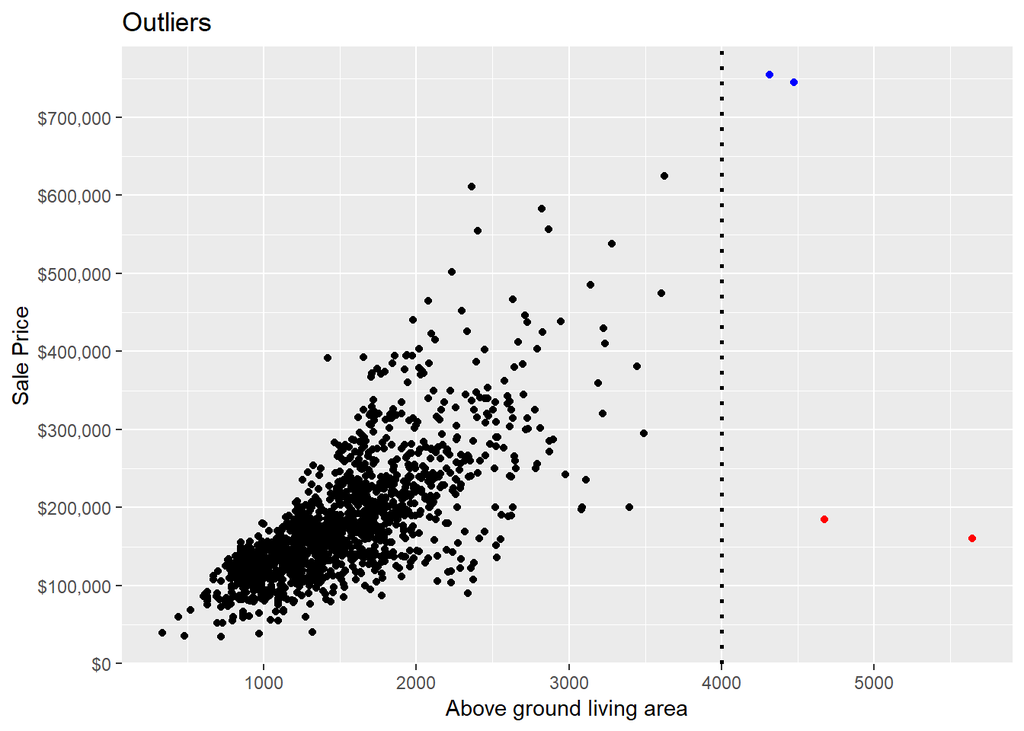

```r
ggplot(data=Full, mapping=aes(x=GrLivArea,y=SalePrice))+
  geom_point(color = ifelse(Full$GrLivArea > 4000&Full$SalePrice<200000, "red",ifelse(Full$GrLivArea > 4000&Full$SalePrice>200000, "blue","black")))+
  geom_vline(xintercept = 4000, linetype="dotted", color = "black",size=1)+
  labs(x='Above ground living area',y='Sale Price', title= 'Outliers')+
  scale_y_continuous(breaks= seq(0, 800000, by=100000), labels = dollar)
```

**Conclusion**

Altough extreme, the two observations in the **top right corner** (in blue) are **in line with the trend** displayed in the data set.

We can however see some outliers that do not fit with the rest of the dataset. We will **remove the two observations from the bottom right quarter** (in red).

Those two houses were valued while not yet completed (`SaleCondition = Partial`). The effect of the variable `SaleCondition` will be explored later in this notebook.

```r
Full%>%filter(Full$GrLivArea>4000&!is.na(Full$SalePrice))%>%select(SaleCondition,SalePrice,GrLivArea)%>%arrange(desc(SalePrice))
```

```
##   SaleCondition SalePrice GrLivArea
## 1        Normal    755000      4316
## 2       Abnorml    745000      4476
## 3       Partial    184750      4676
## 4       Partial    160000      5642
```

```r
cat('Size of the dataset before: ',dim(Full))
```

```
## Size of the dataset before:  2919 80
```

```r
Full<-Full%>%filter(!(Full$GrLivArea>4000&!is.na(Full$SalePrice)&Full$SalePrice<200000))

cat('Size of the dataset after: ',dim(Full))
```

```
## Size of the dataset after:  2917 80
```

# Exploratory data analysis

**Strategy:**

- Pre-processing of the ordinal variables
- Analysis of the distribution of the Sale Price
- Analysis of the interaction between the predictors and the response.

## Categorical variables: recoding the ordinal features

While some features are purely categorical, i.e. qualitative by nature, other features are ordinal: the implicit ordering of their categories contains a predictive information.  
Two different approaches are possible for **ordinal variables**:

- Either we consider them as purely categorical variables, and we one-hot encode them, at the cost of losing the information contained in their natural ordering;
- Or, we encode them as integer, at the cost of introducing an artificial scaling. This technique forces the intervals between the different categories, but respects their natural hierarchy.

In this case, we will chose the second option. The ordinal variables will be recoded with an integer scale that translates their **hierachical order**.

```r
cat("There are",ncol(Full %>% select(which(sapply(Full, class)=="character"))),"categorical variables before encoding")
```

```
## There are 43 categorical variables before encoding
```

```r
#---- define categorical inputs
temp_Qualities <- list('None' = 0, 'Po' = 1, 'Fa' = 2, 'TA' = 3, 'Gd' = 4, 'Ex' = 5)
temp_bmstexp <-list("None"=0,"No"=1,"Mn"=2,"Av"=3,"Gd"=4)
temp_bsmttype <-list('None'=0,'Unf'=1,'LwQ'=2,'Rec'=3,'BLQ'=4,'ALQ'=5,'GLQ'=6)
temp_alley <-list('None'=0,'Grvl'=1,'Pave'=2)
temp_exterqual<-list('Po'=0,'Fa'=1,'TA'=2,'Gd'=3,'Ex'=4)
temp_paved<-list('N'=0,'P'=1,'Y'=2)
temp_garage<-list('None'=0,'Unf'=1,'RFn'=2,'Fin'=3)

#----- encode categorical inputs

Full$Alley<-recode(Full$Alley,!!!temp_alley,.missing=0)
Full$ExterQual<-recode(Full$ExterQual,!!!temp_exterqual,.missing=0)
Full$ExterCond<-recode(Full$ExterCond,!!!temp_exterqual,.missing=0)
Full$BsmtExposure<-recode(Full$BsmtExposure,!!!temp_bmstexp,.missing=0)
Full$BsmtFinType1<-recode(Full$BsmtFinType1,!!!temp_bsmttype,.missing=0)
Full$BsmtFinType2<-recode(Full$BsmtFinType2,!!!temp_bsmttype,.missing=0)
Full$GarageFinish<-recode(Full$GarageFinish,!!!temp_garage,.missing=0)
Full$PavedDrive<-recode(Full$PavedDrive,!!!temp_paved,.missing=0)
Full$BsmtQual<-recode(Full$BsmtQual,!!!temp_Qualities,.missing=0)
Full$BsmtCond<-recode(Full$BsmtCond,!!!temp_Qualities,.missing=0)
Full$HeatingQC<-recode(Full$HeatingQC,!!!temp_Qualities,.missing=0)
Full$KitchenQual<-recode(Full$KitchenQual,!!!temp_Qualities,.missing=0)
Full$GarageQual<-recode(Full$GarageQual,!!!temp_Qualities,.missing=0)
Full$GarageCond<-recode(Full$GarageCond,!!!temp_Qualities,.missing=0)

#clean workspace
rm(list=ls(pattern="temp"))

cat(" There are",ncol(Full %>% select(which(sapply(Full, class)=="character"))),"categorical variables after encoding")
```

```
##  There are 29 categorical variables after encoding
```

## Distribution of the Sale Price

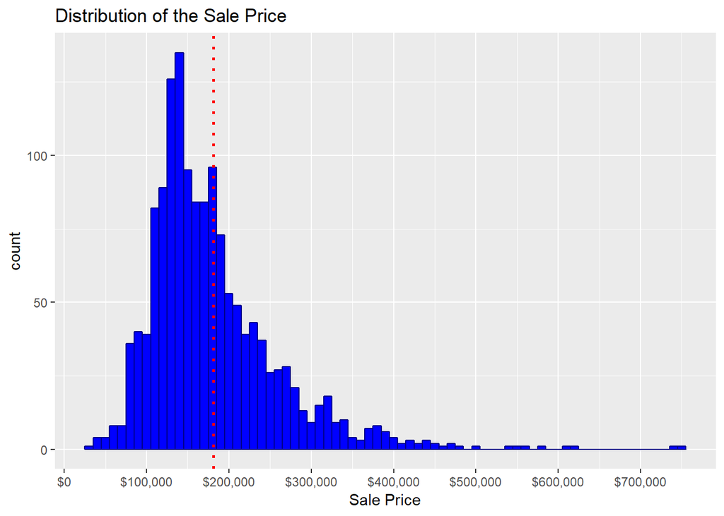

```r
#plot the distribution
ggplot(data=Full[!is.na(Full$SalePrice),], mapping=aes(x=SalePrice)) +
  geom_histogram( binwidth = 10000, main='Sale price before transformation', fill='blue', color='darkblue')+
  labs(x='Sale Price', title= 'Distribution of the Sale Price ')+
  scale_x_continuous(breaks= seq(0, 800000, by=100000), labels = dollar)+
  geom_vline(xintercept = mean(Full$SalePrice,na.rm='true'), linetype="dotted", color = "red",size=1)
```

Unsurprisingly, the Sale Price displays the characteristics a log-normal distribution: **floored to zero, right skewed,** with an accumulation of smaller values below the mean (dotted red line), and a fatter tail on the right side. We will apply a **log transformation**.

```r
  cat("skewness before log-transformation: ",skewness(Full$SalePrice,na.rm=TRUE))
```

```
## skewness before log-transformation:  1.877427
```

```r
Full$SalePrice <- log(Full$SalePrice+1)
   cat("skewness after log-transformation: ",skewness(Full$SalePrice,na.rm=TRUE))
```

```
## skewness after log-transformation:  0.1213297
```

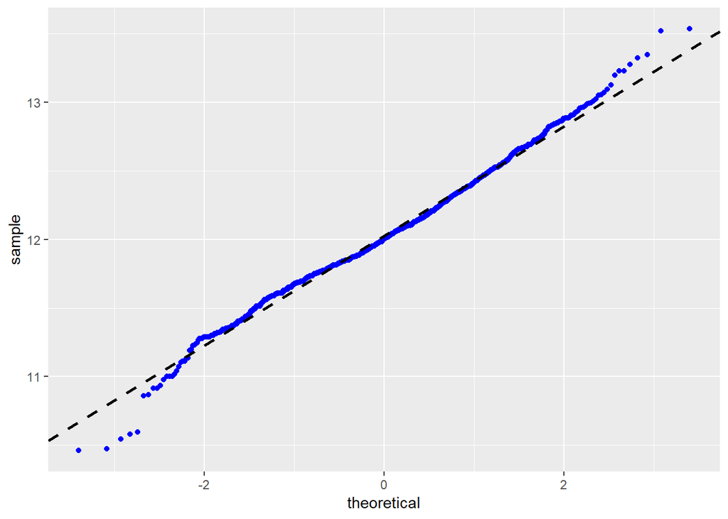

```r
#qqplot
ggplot(data=Full[!is.na(Full$SalePrice),], mapping=aes(sample=SalePrice)) +
  stat_qq(color="blue")+
   geom_abline(intercept = mean(Full$SalePrice,na.rm='true'), slope = sd(Full$SalePrice,na.rm='true'),color="black",linetype="dashed",size=1)
```

The Sale Price after transformation broadly follows a **normal distribution**, despite a higher dispersion in the tail values.

## Interaction of the predictors with the Sale price

### Correlation between the numerical variables and the Sale Price

First, let’s focus on the **numerical variables**

```r
Full_numeric<-Full[!is.na(Full$SalePrice),names(select_if(Full, is.numeric))]
```

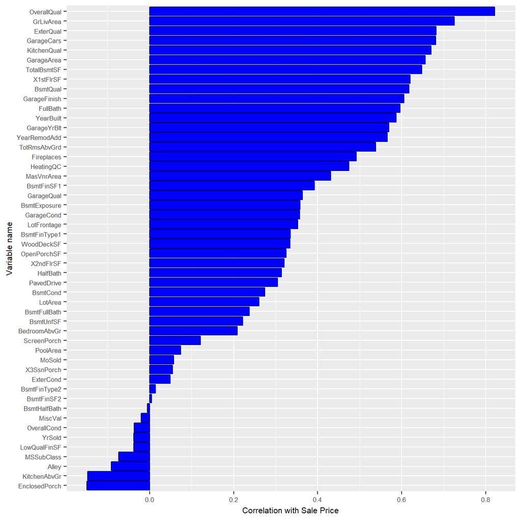

```r
Correlation_table <- Full_numeric %>%
  correlate() %>%
  focus(SalePrice)


Correlation_table %>%
  mutate(rowname = factor(rowname, levels = rowname[order(SalePrice)])) %>%  # Order by correlation strength
  ggplot(aes(x = rowname, y = SalePrice)) +
  geom_bar(stat = "identity", fill='blue', color='darkblue')+
  coord_flip()+ #vertical aligment
  scale_x_discrete(name = "Variable name") +
  scale_y_continuous(name = "Correlation with Sale Price") +
  theme(text = element_text(size=8))
```

- The most influential variables are the **overall quality** (`OverallQual`) of the house and the **living area** (`GrLivArea`).
- 3 out of the 10 most correlated predictors are garage related variables. This indicates a **high level of collinearity** in the dataset, which we will investigate later.
- Some predictors appear to **negatively influence** the sale price, for attributes that appear to be counter-intuitive. Most of them are ‘low quality’ data with **insufficient variance**. We will remove those predictors from the dataset (Alley, Kitchens above grade, etc…)
- As expected, the age of the house or of the last renovation negatively impacts its sale price (`YearBuilt`, `YearRemodAdd`).

### Overal correlation within the dataset

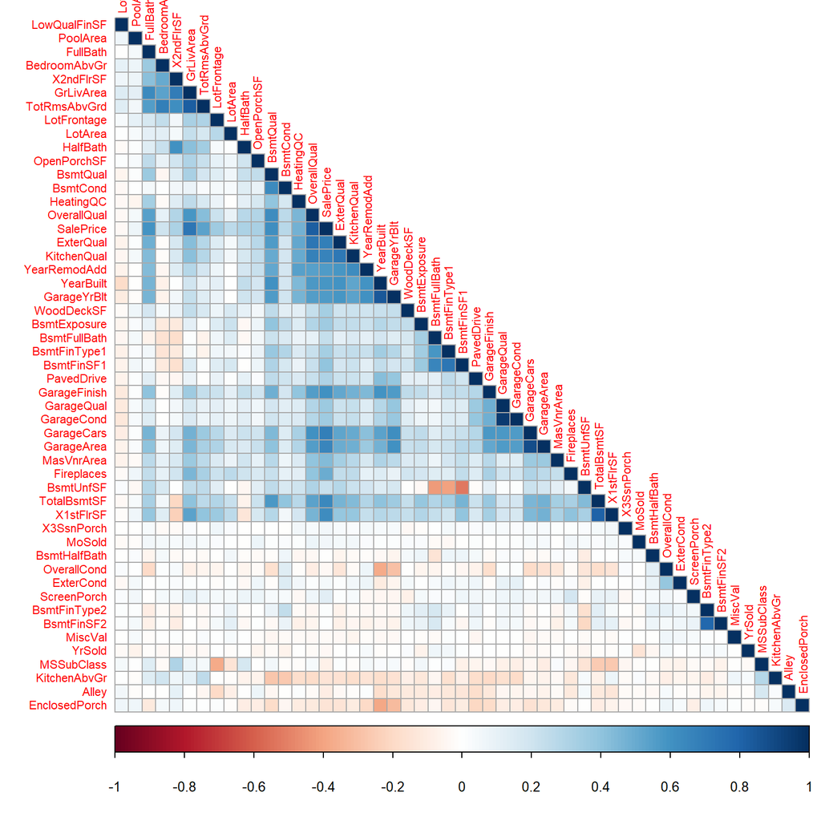

Overall, there is a high degree of collinearity in the dataset, and we will need to select models that are robust to correlation.

We note **clusters of collinearity** mainly between the **garage** variables and the **house area/number of rooms** variables.

# Feature engineering

**Strategy:**

- Rationalisation of the categorical variables with unbalanced classes
- Feature extraction
  - Creation of additional variables
  - Analysis of Neighborhood and Date Sold.

## Rationalisation of the categorical variables

There is some noise induced by the **scarcity of data** in some of the categories. We will adress this by **grouping** some of the values into more stable classes.

```r
#define the graphs 'before changes'

g1<-ggplot(data=Full[!is.na(Full$SalePrice),], aes(x=as.factor(LotShape),y=exp(SalePrice)-1))+
  geom_boxplot()+
  geom_label(stat = "count", aes(label = ..count.., y = ..count..), size=3)+
  labs(x="Lot Shape before",y='')+
  scale_y_continuous(breaks= seq(0, 800000, by=200000), labels = comma)

g3<-ggplot(data=Full[!is.na(Full$SalePrice),], aes(x=as.factor(Functional),y=exp(SalePrice)-1))+
  geom_boxplot()+
  geom_label(stat = "count", aes(label = ..count.., y = ..count..), size=3)+
  labs(x="Functional before",y='')+
  scale_y_continuous(breaks= seq(0, 800000, by=200000), labels = comma)

g5<-ggplot(data=Full[!is.na(Full$SalePrice),], aes(x=as.factor(OverallQual),y=exp(SalePrice)-1))+
  geom_boxplot()+
  geom_label(stat = "count", aes(label = ..count.., y = ..count..), size=3)+
  labs(x="Overall Quality before",y='')+
  scale_y_continuous(breaks= seq(0, 800000, by=200000), labels = comma)

g7<-ggplot(data=Full[!is.na(Full$SalePrice),], aes(x=as.factor(SaleCondition),y=exp(SalePrice)-1))+
  geom_boxplot()+
  geom_label(stat = "count", aes(label = ..count.., y = ..count..), size=3)+
  labs(x="Sale condition before",y='')+
  scale_y_continuous(breaks= seq(0, 800000, by=200000), labels = comma)

g9<-ggplot(data=Full[!is.na(Full$SalePrice),], aes(x=as.factor(Electrical),y=exp(SalePrice)-1))+
  geom_boxplot()+
  geom_label(stat = "count", aes(label = ..count.., y = ..count..), size=3)+
  labs(x="Electrical system before",y='')+
  scale_y_continuous(breaks= seq(0, 800000, by=200000), labels = comma)
```

```r
Full$CentralAir<-recode(Full$CentralAir,'N'=0,'Y'=1,.missing=0)
Full$LotShape <- factor(ifelse(Full$LotShape=='Reg', 'Regular', 'Irregular'))
Full$Functional <- factor(ifelse(Full$Functional=='Typ', 'Typical', 'NonTypical'))
Full$Electrical <-factor(ifelse(Full$Electrical=="SBrkr",1,0))
OverallQualtemp<-Full$OverallQual#placeholder to create a global variable with Overall Qual
OverallCondtemp<-Full$OverallCond
Full$OverallQual[Full$OverallQual==10]<-9
Full$OverallQual[Full$OverallQual<4]<-3
Full$OverallQual<-Full$OverallQual-2 #range 1-7, will be scaled
Full$OverallCond<- ifelse(Full$OverallCond<5,4,ifelse(Full$OverallCond>7,8,Full$OverallCond))
Full$OverallCond<-Full$OverallCond-3# range 1-5, will be scaled

Full$TotRmsAbvGrd[Full$TotRmsAbvGrd<4]<-4
Full$TotRmsAbvGrd[Full$TotRmsAbvGrd>10]<-10

Full$Fireplaces<- ifelse(Full$Fireplaces>0,1,0)


Full$Proximity <-1
Full$Proximity[Full$Condition2=='Artery']<-0
Full$Proximity[Full$Condition1 %in% c('Artery','Feedr')]<-0
Full$Proximity[Full$Condition1 %in% c('PosN','PosA')]<-2
Full$SaleCondition<-ifelse(Full$SaleCondition =="Partial","Partial",ifelse(Full$SaleCondition =="Normal","Normal","Other"))


Full$HouseStyle<-factor(recode(Full$HouseStyle,'1.5Fin'= '1.5','1.5Unf'= '1.5','1Story'='1' ,'2.5Fin'= '2','2.5Unf'= '2','2Story'='2' ,'SFoyer'='Split' ,'SLvl'='Split' ))
```

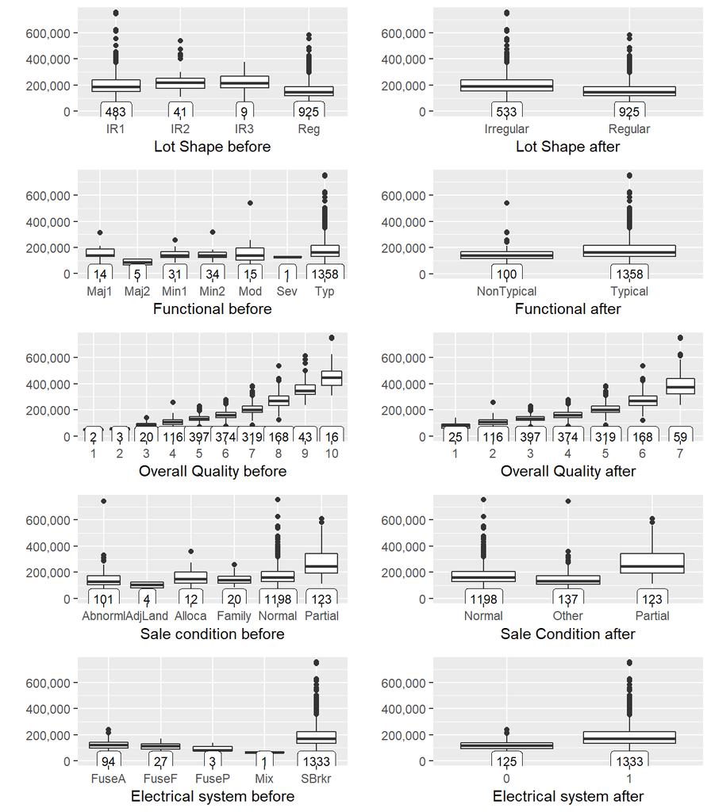

```r
#define the graphs afer change
g2<-ggplot(data=Full[!is.na(Full$SalePrice),], aes(x=as.factor(LotShape),y=exp(SalePrice)-1))+
  geom_boxplot()+
  geom_label(stat = "count", aes(label = ..count.., y = ..count..), size=3)+
  labs(x="Lot Shape after",y='')+
  scale_y_continuous(breaks= seq(0, 800000, by=200000), labels = comma)

g4<-ggplot(data=Full[!is.na(Full$SalePrice),], aes(x=as.factor(Functional),y=exp(SalePrice)-1))+
  geom_boxplot()+
  geom_label(stat = "count", aes(label = ..count.., y = ..count..), size=3)+
  labs(x="Functional after",y='')+
  scale_y_continuous(breaks= seq(0, 800000, by=200000), labels = comma)

g6<-ggplot(data=Full[!is.na(Full$SalePrice),], aes(x=as.factor(OverallQual),y=exp(SalePrice)-1))+
  geom_boxplot()+
  geom_label(stat = "count", aes(label = ..count.., y = ..count..), size=3)+
  labs(x="Overall Quality after",y='')+
  scale_y_continuous(breaks= seq(0, 800000, by=200000), labels = comma)

g8<-ggplot(data=Full[!is.na(Full$SalePrice),], aes(x=as.factor(SaleCondition),y=exp(SalePrice)-1))+
  geom_boxplot()+
  geom_label(stat = "count", aes(label = ..count.., y = ..count..), size=3)+
  labs(x="Sale Condition after",y='')+
  scale_y_continuous(breaks= seq(0, 800000, by=200000), labels = comma)

g10<-ggplot(data=Full[!is.na(Full$SalePrice),], aes(x=as.factor(Electrical),y=exp(SalePrice)-1))+
  geom_boxplot()+
  geom_label(stat = "count", aes(label = ..count.., y = ..count..), size=3)+
  labs(x="Electrical system after",y='')+
  scale_y_continuous(breaks= seq(0, 800000, by=200000), labels = comma)
grid.arrange(g1, g2,g3,g4,g5,g6,g7,g8,g9,g10, ncol = 2)
```

```r
rm(g1,g2,g3,g4,g5,g6,g7,g8,g9,g10)
```

We now have more stable classes. This step has helped reduce the number of **near zero variance predictors**.  
The remaining ones will be addressed during the preparation of the analysis.

As a quick note, we can notice that most variables have a number of **outliers**. It wouldn’t be practical to address them one by one, so we will need to carefully to select algorithms that are robust to outliers.

## Feature extraction

### Creation of new variables

**Stategy:**

Creation of:

- Age related variables:
  - Age of the house,
  - Age of the renovation,
  - New: flags if the house is new
  - Vintage: decade of the house
- Condition related variables:
  - OverallCombi, is a combination of Overall condition and Overall Quality
  - ExteriorCombi, is a combination of Exterior Condition and Exterior Quality
  - GarageCombi, is a combination of Garage Conditin and Garage Quality
- Outdoor area, is the Total lot area - basement surface - garage surface
- Total porch surface
- Bathroom related:
  - Total number of bathrooms
  - Number of bathroom per number of room (Too many wouldn’t be convenient, no one likes to scrub bathrooms :-)
- PUD, for planned unit development. This is the only additional information brought by the variable `MSSubClass`, all other information relating to the number of storeys are already available in the variable `HouseStyle`.

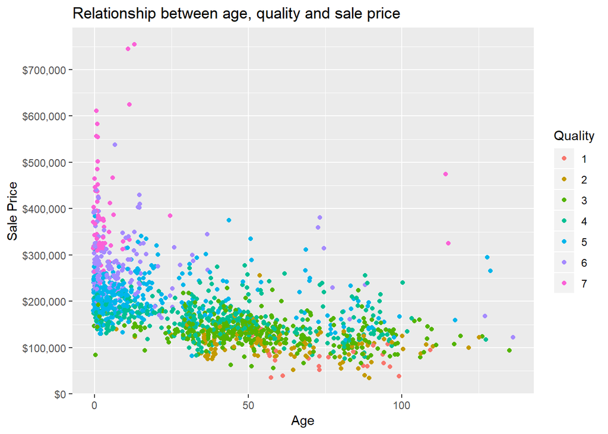

```r
redundant<-NULL #init, vector will be used to store the names of the variables no longer needed

#--- Age related variables ---
Full<-Full%>%mutate(Age=as.integer(YrSold) - as.integer(YearBuilt))
Full$Age<-ifelse(Full$Age<0,0,Full$Age)
Full$New<-ifelse(Full$Age==0,1,0)
# qplot(Full$Age,Full$SalePrice)

Full<-Full%>%mutate(AgeReno=as.integer(YrSold)-as.integer(YearRemodAdd))
Full$AgeReno<-ifelse(Full$AgeReno<0,0,Full$AgeReno)
Full$AgeReno<-ifelse(Full$AgeReno==Full$Age,0,Full$AgeReno)

Full$Vintage<-ifelse(as.integer(Full$YearBuilt)<1900,'1900s',paste(as.character(as.integer(Full$YearBuilt)%/%10),'0s',sep= ''))
# table(Full$Vintage, useNA = 'always')
redundant<-c(redundant,'YearRemodAdd','YearBuilt')



# --- Condition related variables ---
Full<-Full%>%mutate(ExteriorCombi=as.integer(ExterQual) * as.integer(ExterCond))
Full<-Full%>%mutate(OverallCombi=as.integer(OverallQualtemp) * as.integer(OverallCondtemp))
Full<-Full%>%mutate(GarageCombi=as.integer(GarageCond) * as.integer(GarageQual))
Full<-Full%>%mutate(Outdoors=LotArea-TotalBsmtSF-GarageArea)
# --- Porch surface ---
Full<-Full%>%mutate(Porch=OpenPorchSF+EnclosedPorch+ScreenPorch+X3SsnPorch)
redundant<-c(redundant, 'OpenPorchSF','EnclosedPorch','ScreenPorch','X3SsnPorch')

# --- Bathroom related variables ---
Full<-Full%>%mutate(Bathrooms=BsmtHalfBath*0.5+BsmtFullBath+HalfBath*0.5+FullBath)
Full<-Full%>%mutate(BathPerRoom = Bathrooms / TotRmsAbvGrd)
#Full$Bathrooms[Full$Bathrooms>4]<-4
redundant<-c(redundant,'BsmtHalfBath','BsmtFullBath','HalfBath','FullBath')

# --- Planned Unit Development
pudlist<-c(120,150,160,180)
Full$PUD<-ifelse(Full$MSSubClass %in% pudlist,1,0)
redundant<-c(redundant,'MSSubClass')

#clean up the environement
  rm(OverallCondtemp,OverallQualtemp,pudlist)


ggplot(data=Full[!is.na(Full$SalePrice),], mapping=aes(x=Age,y=exp(SalePrice)-1, color=as.factor(OverallQual)))+
  geom_jitter()+
  labs(x='Age',y='Sale Price', title= 'Relationship between age, quality and sale price',color='Quality')+
  scale_y_continuous(breaks= seq(0, 800000, by=100000), labels = dollar)
```

### Neighborhood

We can see **four diffent classes** emerge from the neigborhood.  
We will create an ordinal variable (`Suburb`) to summarise the Neighborhood price category.

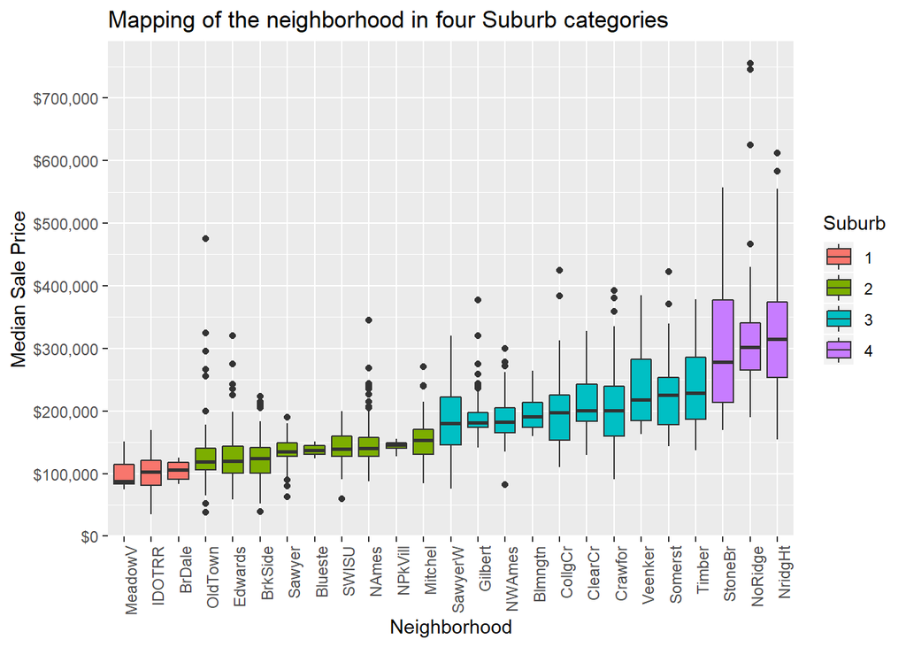

```r
Full$Suburb<- ifelse(Full$Neighborhood %in%c('NoRidge','NridgHt','StoneBr'),4,
              ifelse(Full$Neighborhood %in% c('BrDale','IDOTRR','MeadowV'),1,
              ifelse(Full$Neighborhood %in% c( 'Timber','Veenker','Somerst',                                        'Crawfor','ClearCr','CollgCr','Blmngtn',                                       'Gilbert','NWAmes','SawyerW'),3,
               2)))


ggplot(data=Full[!is.na(Full$SalePrice),], aes(x=reorder(Neighborhood ,SalePrice, FUN = median), y=exp(SalePrice)-1, fill=as.factor(Suburb)))+
  geom_boxplot()+
  labs(x='Neighborhood',y='Median Sale Price', title= 'Mapping of the neighborhood in four Suburb categories',fill='Suburb')+
  scale_y_continuous(breaks= seq(0, 800000, by=100000), labels = dollar)+
        theme(axis.text.x = element_text(angle = 90, hjust = 1))
```

```r
 redundant<-c(redundant,'Neighborhood')
```

### Impact of date sold

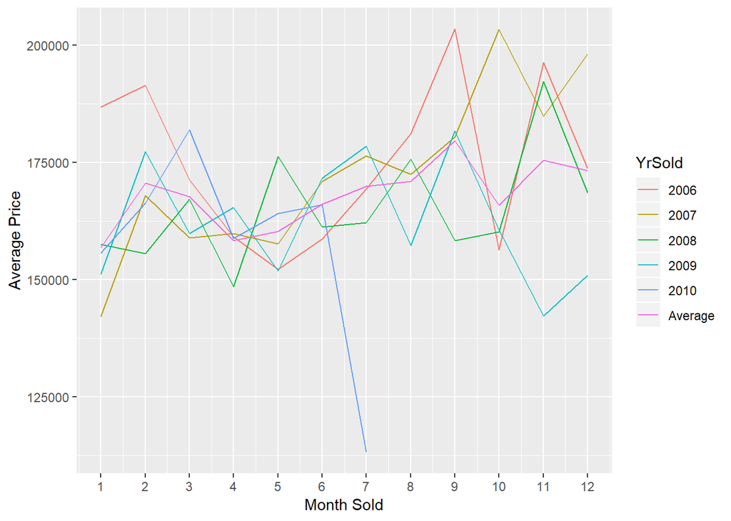

```r
# -- Create a subtable - summarize average by year&month
AverageByMonth<-Full%>%filter(!is.na(SalePrice))%>%group_by(YrSold,MoSold)%>%summarise( meanprice=mean(SalePrice))
AverageByMonth$YrSold<-factor(AverageByMonth$YrSold)
AverageGlobal<-Full%>%filter(!is.na(SalePrice))%>%group_by(MoSold)%>%summarise(meanprice=mean(SalePrice))
AverageGlobal$YrSold <-"Average"
temp <- data.frame(matrix(nrow=6,ncol=3))
colnames(temp)<-c('YrSold','MoSold','meanprice')

# -- fill year 2010 as no data after July
for (i in 1:6){
  temp$YrSold[i]<-'2010'
  temp$MoSold[i]<-6+i
  temp$meanprice[i] <- NA
}
rm(i)

ImpactDateSold<-bind_rows(AverageByMonth, temp, AverageGlobal)

# -- Plot
ggplot(data=ImpactDateSold, aes(x=MoSold, y=exp(meanprice)-1,group= ImpactDateSold$YrSold) )+
  geom_line( aes(color = YrSold)) +
  scale_x_continuous(breaks= seq(1,12))+
    labs(x="Month Sold",y='Average Price')
```

```r
rm(AverageByMonth, temp, AverageGlobal, ImpactDateSold)
```

Note that there are no data available after July 2010. There is no obvious influence at first sight of the sale date on the Sale price. Let’s explore this further…

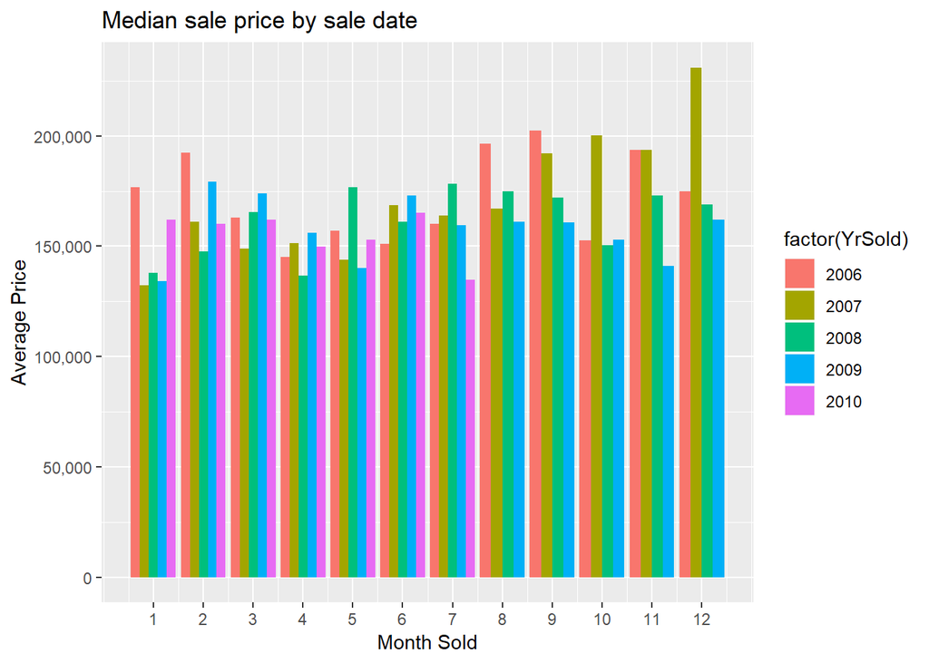

```r
 ggplot(data=Full[!is.na(Full$SalePrice),], aes(x=MoSold, y=exp(SalePrice)-1, fill= factor(YrSold)) )+
       geom_bar(stat='summary', fun.y = "median", position = 'dodge')+
    labs(x="Month Sold",y='',title= 'Median sale price by sale date')+
  scale_y_continuous(breaks= seq(0, 800000, by=50000), labels = comma)+
  scale_x_continuous(breaks= seq(1,12))+
    labs(x="Month Sold",y='Average Price')
```

The effects of the crisis of 2007 can be observed but are quite tenuous, and the seasonality by contrast plays a more important role. The low median value for July 2010 is influenced by the low number of sales data available that month.

### Drop the variables that are no longer needed

We remove the variables made redundant by the new variables created during the feature engineering .

```r
cat("remove the vars" ,redundant)
```

```
## remove the vars YearRemodAdd YearBuilt OpenPorchSF EnclosedPorch ScreenPorch X3SsnPorch BsmtHalfBath BsmtFullBath HalfBath FullBath MSSubClass Neighborhood
```

```r
Full<-Full%>%select(-one_of(redundant))
rm(redundant)
```

We also remove the variables that have **too many missing observations** to be meaningful.

```r
smallvar<-c('Condition1','Condition2',
     'Heating','FireplaceQu','PoolArea','MiscVal','MiscFeature', 'KitchenAbvGr', 'Alley','Condition1','Condition2','LowQualFinSF')

cat("remove the vars" ,smallvar)
```

```
## remove the vars Condition1 Condition2 Heating FireplaceQu PoolArea MiscVal MiscFeature KitchenAbvGr Alley Condition1 Condition2 LowQualFinSF
```

```r
Full<-Full%>%select(-one_of(smallvar))
rm(smallvar)
```

```r
#redundant<-c(redundant,'X1stFlrSF' , 'X2ndFlrSF','LowQualFinSF')
garagevar<-c( 'GarageYrBlt', 'GarageArea', 'GarageCond')
Full<-Full%>%select(-one_of(garagevar))
rm(garagevar)
```

# Pre-Processing

Let’s get the dataset ready for the predictive analysis.

**Strategy:**

- Split the dataset between the *predictors* and the *response*
- Categorical variables : remove the variables with a near-zero variance, and one-hot encode them
- Numeric variables: center, scale, and normalize
- Split between *train* (development) and *test* (validation) sets

```r
#split between predictors and sale price
  Response<-Full%>%select(SalePrice)
  Predictors<-Full%>%select(-one_of('SalePrice'))

  dim(Predictors)
```

```
## [1] 2917   68
```

```r
  dim(Response)
```

```
## [1] 2917    1
```

## Categorical variables

Most machine learning algorithms cannot work directly with categorical data, and require them to be converted to numeric values.  
We will one-hot encode the categorical variables as **dummy variables**.

```r
# --- Encode 'false integer' as factor
Full <- Full %>% mutate(
  MoSold=factor(MoSold),
  YrSold=factor(YrSold))
#identify the categorical variables
factorvar<-names(select_if(Predictors, Negate(is.numeric)))
PredFactors <-Predictors[,factorvar]


# --- creation of dummy vars
dummies <- dummyVars( ~ ., data = PredFactors, fullRank=T) #fullRank to have n-1 dummies => avoid dummyvartrap
PredFactors<-predict(dummies, newdata = PredFactors)
rm(dummies)
```

Let’s also remove the predictors that have a **near-zero variance**: i.e. either those which have a single unique category, or those with very few distinct different categories other than the most common one.

```r
nzv <-nearZeroVar(PredFactors, freqCut = 97/3,uniqueCut = 10, saveMetrics = FALSE,names = FALSE)
cat('the following variables will be removed',colnames(PredFactors[,nzv]))
```

```
## the following variables will be removed MSZoningRH StreetPave LandContourLow UtilitiesNoSeWa LotConfigFR2 LotConfigFR3 LandSlopeSev BldgType2fmCon RoofStyleGambrel RoofStyleMansard RoofStyleShed RoofMatlMembran RoofMatlMetal RoofMatlRoll RoofMatlTar&Grv RoofMatlWdShake RoofMatlWdShngl Exterior1st…
```

```r
PredFactors <- PredFactors[, -nzv]
rm(nzv)
```

## Numeric predictors:

Let’s select the numeric variables in the dataset:

```r
#identify the numeric variables
numericvar <-names(select_if(Predictors, is.numeric))
PredNumeric <-Predictors[,numericvar]
rm(numericvar)
```

We now apply a **Box-Cox transformation** to **normalise** the data.

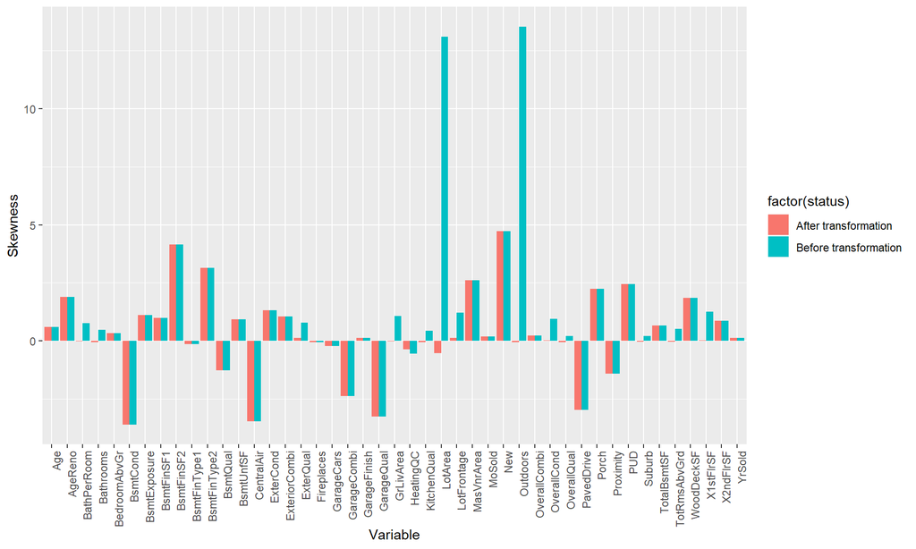

```r
#collect the values before
  Transfo <- data.frame(matrix(nrow=2*dim(PredNumeric)[2],ncol=3))
  colnames(Transfo)<-c('Variable','Skewness','status')
  before<-(1:dim(PredNumeric)[2])
  Transfo$Variable[before] <- colnames(PredNumeric)
  Transfo$Skewness[before] <- apply(PredNumeric, 2, skewness)
  Transfo$status[before]<-"Before transformation"

#This is where I apply the normalisation
  Skewtrans <- preProcess(PredNumeric, method =c('BoxCox'))#,'BoxCox'"YeoJohnson")
  PredNumeric<- predict(Skewtrans , PredNumeric)


  #Collect the values after
  a<-dim(PredNumeric)[2]+1
  b<-2*dim(PredNumeric)[2]
  after<-(a:b)

  Transfo$Variable[after] <- colnames(PredNumeric)
  Transfo$Skewness[after] <- apply(PredNumeric, 2, skewness)
  Transfo$status[after]<-"After transformation"

ggplot(Transfo, aes(x=Variable, y=Skewness,fill=factor(status))) +
        geom_bar(stat='identity',position='dodge') +
        theme(axis.text.x = element_text(angle = 90, hjust = 1))
```

```r
rm(Transfo, a,b,before, after,Skewtrans)
```

And we **center** and **scale** the predictors.

```r
 centerscale <- preProcess(PredNumeric, method =c("center", "scale"))
PredNumeric<- predict(centerscale , PredNumeric)
rm(centerscale)
```

## Put everything together, create the train and test samples

**Strategy:**

- Merge the numeric and categorical features in one single predictor dataset.
- Separate the data that will be used for the Kaggle submission from those that will be used to train and evaluate the models locally.
- Create the train and test datasets.

Merge the datasets.

```r
  cat('There are ',dim(PredNumeric)[2], 'numeric variables and', dim(PredFactors)[2],'categorical variables')
```

```
## There are  45 numeric variables and 57 categorical variables
```

```r
  Predictors<-cbind(PredFactors,PredNumeric)
```

Separate the ‘local’ data from the Kaggle submission.

```r
  Predictors_sub<-Predictors[is.na(Response),]
  Predictors<-Predictors[!is.na(Response),]
  Response_sub<-Response[is.na(Response)]
  Response<-Response[!is.na(Response)]
  rm(PredFactors, PredNumeric)
cat('The size of the development dataset is ',dim(Predictors))
```

```
## The size of the development dataset is  1458 102
```

### Create the train and test partition

Note that this step is not formally necessary in the context of a Kaggle competition, as the submission could implicitly be used as a test set.  
Splitting the dataset will enable us to estimate the fitting quality of the model: a model with very optimistic training results and bad test results will most likely be over-fitted.  
We will use a 80%-20% treshold for the train/test split.

```r
set.seed(2018)
datasplit<-createDataPartition(Response,p=0.8 )[[1]]

trainPredictors<-Predictors[datasplit,]
validationPredictors<-Predictors[-datasplit,]
trainResponse<-Response[datasplit]
validationResponse<-Response[-datasplit]
rm(datasplit,Predictors, Response)
```

The dataset is finally ready for the predictive modeling, this is where the fun begins :-)

# Predictive modeling

## Round 1: Base models

We will fit a first selection of regression models. The most interesting ones will later be used as base layer for the construction of a meta-model.

The models we will fit in this section are:

1. a Lasso
2. an Elastic Net
3. a Support vector machine (radial kernel)
4. a Regression Spline (MARS model)
5. a Random Forest
6. a Gradient Boosting algorithm
7. an XGBoost model

We will evaluate the models based on their **root mean squared error (RMSE)**.  
This is a natural metric to use for this type of regression analysis, and this is the one used to establish the ranking for the Kaggle competition.

### Model tuning

First, let’s define, for each model, a set of tuning parameters. We will identify the most adequate ones with a k-fold cross validation.

```r
set.seed(2018)

#define 10 fold cross validation, repeated 3 times
control<-trainControl(method='repeatedcv',repeats=3,number=10,
                       #savePredictions = "all",#useful for debugging
                       allowParallel = TRUE,savePredictions = TRUE)

#--- define the tuning grids for grid search tuning ---

LassoGrid<-expand.grid(fraction=seq(0.05,1,length=20)) #lamda = 0

EnetGrid<-expand.grid(lambda = c(0.001, 0.01, 0.05),#lamda = ridge penalty
                        fraction=seq(0.05,1,length=20))


MarsGrid<-expand.grid(.degree = 1:2, .nprune =seq( 5,50,by=5))

RFGrid = expand.grid(mtry=c(40,50,60))#number of predictors randomly sampled,I took npred /3 and extanded to npred /2
                        #default= 500

GBMGrid <- expand.grid(interaction.depth = seq(1, 7, by = 2),
                          n.trees = seq(100, 1000, by = 50),
                         shrinkage = c(0.01, 0.05,0.1),
                          n.minobsinnode = 10)
XGBGrid <- expand.grid(
       nrounds = c(100,200),
       eta = c(0.3, 0.05), #learning rate
       max_depth = c(2,  4, 5,15, 20, 25 ),#Maximum depth of each trained tree, !overfitting
       colsample_bytree=0.7,#1#Percentage of columns used per iteration.
       gamma = 0,
       min_child_weight = 1,
       subsample=0.8)#1)#percentage of rows used by iteration
#https://sites.google.com/view/lauraepp/parameters
```

Let’s now train each model on those grid of parameters.

```r
#--- parallel computing --
cluster <- makeCluster(detectCores() - 1) #All cores minus 1 for OS
registerDoParallel(cluster) #Parallel computing on available cores

#--- fit the models ---
#t<- Sys.time()
LassoTuned <-train(x=trainPredictors, y= trainResponse,
                    method="lasso", #elasticnet package
                    tuneGrid = LassoGrid,
                    trControl = control)
EnetTuned<-train(x=trainPredictors, y= trainResponse,
                    method="enet", #elasticnet package
                    tuneGrid = EnetGrid,
                    trControl = control)
SVMTuned<-train(x=trainPredictors, y= trainResponse,
                    method="svmRadial",
                    tuneLength = 15,
                    trControl = control)
MarsTuned<-train(x=trainPredictors, y= trainResponse,
                    method="earth", #elasticnet package
                    tuneGrid = MarsGrid,
                    trControl = control)
RFTuned<-train(x=trainPredictors, y= trainResponse,
                    method="rf",
                    tuneGrid = RFGrid,
                    #prox=TRUE,
                    allowParallel=TRUE,ntrees = 1000,
                    trControl = control)
GBMTuned <- train(x=trainPredictors, y= trainResponse,
                    method = "gbm",
                    tuneGrid = GBMGrid,
                    trControl = control,
                    verbose = FALSE)
XGBTuned <- train(x=trainPredictors, y= trainResponse,
                     method = "xgbTree",
                    trControl = control,
                    tuneGrid = XGBGrid)
stopCluster(cluster)
registerDoSEQ()
```

### Results

Now that each model has been tuned, we first need to collect the cross validation results:

```r
#--- Initialise the matrix that will be used to collect the results --
Results<- data.frame(Model = character(),
                        TrainVal=double(),
                        TestVal=double())

Development <-data.frame(matrix(nrow=length(trainResponse),ncol=8))
Validation <-data.frame(matrix(nrow=length(validationResponse),ncol=8))
#Development = on train dataset, Validation on test dataset

colnames(Validation)<-c('Observed','Lasso','Enet','SVM','Mars','RF','GBM','XGB')
colnames(Development)<-c('Observed','Lasso','Enet','SVM','Mars','RF','GBM','XGB')

#--- Collect the response
Validation$Observed<-validationResponse
Development$Observed<-trainResponse

#--- Collect the predictions for each model + RMSE ---
Validation$Lasso<- predict(LassoTuned, newdata = validationPredictors)
Development$Lasso<- predict(LassoTuned, newdata = trainPredictors)
temp<-data.frame(Model='Lasso',
                TrainVal=LassoTuned$results[which.min(LassoTuned$results[, "RMSE"]),"RMSE" ],
                Testval = RMSE(validationResponse,Validation$Lasso))
Results<-rbind(Results,temp)

Validation$Enet<- predict(EnetTuned, newdata = validationPredictors)
Development$Enet<- predict(EnetTuned, newdata = trainPredictors)
temp<-data.frame(Model='Enet',
                TrainVal=EnetTuned$results[which.min(EnetTuned$results[, "RMSE"]),"RMSE" ],
                Testval = RMSE(validationResponse,Validation$Enet))
Results<-rbind(Results,temp)

Validation$SVM<- predict(SVMTuned, newdata = validationPredictors)
Development$SVM<- predict(SVMTuned, newdata = trainPredictors)
temp<-data.frame(Model='SVM',
                TrainVal=SVMTuned$results[which.min(SVMTuned$results[, "RMSE"]),"RMSE" ],
                Testval = RMSE(validationResponse,Validation$SVM))
Results<-rbind(Results,temp)

Validation$Mars<- predict(MarsTuned, newdata = validationPredictors)
Development$Mars<- predict(MarsTuned, newdata = trainPredictors)
temp<-data.frame(Model='Mars',
                TrainVal=MarsTuned$results[which.min(MarsTuned$results[, "RMSE"]),"RMSE" ],
                Testval = RMSE(validationResponse,Validation$Mars))
Results<-rbind(Results,temp)

Validation$RF<- predict(RFTuned, newdata = validationPredictors)
Development$RF<- predict(RFTuned, newdata = trainPredictors)
temp<-data.frame(Model='RF',
                TrainVal=RFTuned$results[which.min(RFTuned$results[, "RMSE"]),"RMSE" ],
                Testval = RMSE(validationResponse,Validation$RF))
Results<-rbind(Results,temp)

Validation$GBM<- predict(GBMTuned, newdata = validationPredictors)
Development$GBM<- predict(GBMTuned, newdata = trainPredictors)
temp<-data.frame(Model='GBM',
                TrainVal=GBMTuned$results[which.min(GBMTuned$results[, "RMSE"]),"RMSE" ],
                Testval = RMSE(validationResponse,Validation$GBM))
Results<-rbind(Results,temp)

Validation$XGB<- predict(XGBTuned, newdata = validationPredictors)
Development$XGB<- predict(XGBTuned, newdata = trainPredictors)
temp<-data.frame(Model='XGB',
                TrainVal=XGBTuned$results[which.min(XGBTuned$results[, "RMSE"]),"RMSE" ],
                Testval = RMSE(validationResponse,Validation$XGB))
Results<-rbind(Results,temp)

rm(temp)
```

Now that we have collected all the results, let’s have a look at the RMSE, obtained on the train and test sets.

```r
Results
```

```
##   Model  TrainVal   Testval
## 1 Lasso 0.1104002 0.1291694
## 2  Enet 0.1108734 0.1289448
## 3   SVM 0.1196534 0.1349041
## 4  Mars 0.1200289 0.1456140
## 5    RF 0.1240334 0.1372155
## 6   GBM 0.1148763 0.1297019
## 7   XGB 0.1169241 0.1328620
```

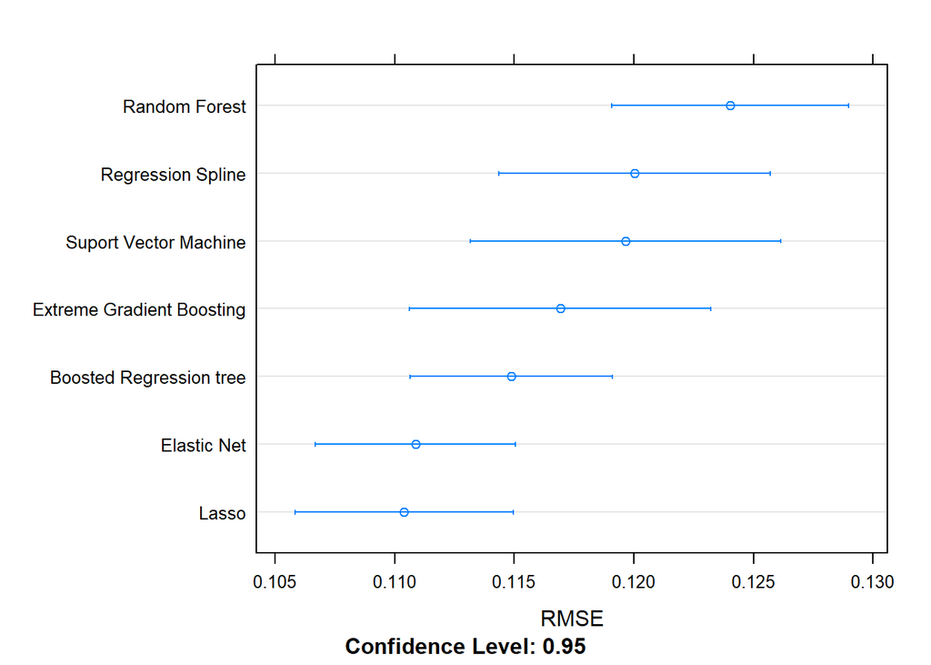

```r
resamples<-resamples(list('Lasso'=LassoTuned,'Elastic Net'=EnetTuned,'Suport Vector Machine' = SVMTuned,'Random Forest'=RFTuned,'Regression Spline' = MarsTuned,'Boosted Regression tree'=GBMTuned, 'Extreme Gradient Boosting'=XGBTuned ))
dotplot(resamples,metric="RMSE")
```

We can observe from the graph and table above that:

- The lasso and elastic net achieve similar performances and lead the pack. This is not surprising as the elastic net is a generalisation of lasso and ridge regression models.
- The extreme gradient boosting has not lived up to its reputation and does not outpeform a classic gradient boosting algorithm.
- The support vector machine and regression spline perform comparably on the train set. However the support vector machine is the one that generalises the best on the test set.
- The random forest does not perform well on this problem.

Let’s also have a look at the residuals…

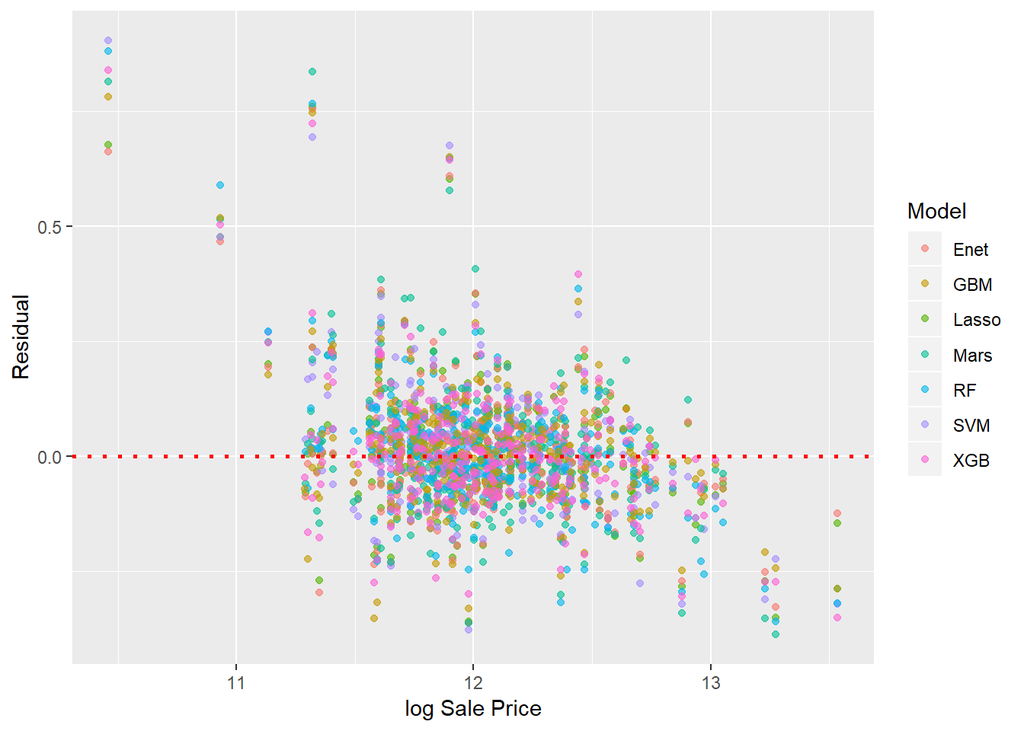

```r
plotdata<-gather(Validation,key = Model,value = Prediction,Lasso, Enet,SVM,Mars,RF,GBM, XGB)

ggplot(data=plotdata, aes(x=Observed, y=Prediction-Observed, color=Model))+

geom_jitter(alpha = 0.6)+ labs(x="log Sale Price",y='Residual')+
  geom_hline(yintercept = 0, linetype="dotted", color = "red",size=1)
```

### Conclusion

Based on the analysis above, and in order to maximise the algorithms diversity among the base model, we will proceed with:

- Elastic Net
- Gradient boosting
- Regression spline
- Support vector machine

## Round 2, construction of a meta-model

**Strategy:**

We will evaluate 3 different types of meta-models:

- The first one will be a simple **stacking**, based on a a weighted averaging of the base models results,
- The second one will be an unconstrained linear regression,
- And the last one will be a random forest.

As a reminder, at this stage, the `Development` and `Validation` dataframes each contain 8 columns: the first one contains the actual Sale price, while the 7 other ones contain the predictions generated by the first round of predictive models.

### Linear combination

We start with a ‘naive’ ensembling, as a **linear combination** of the underlying models. We force the sum of the weights to equal 1

```r
# weights allocated to {observed lasso enet svm mars rf gbm xgb}
blendweight=c(0,0,0.2,0.2,0.2,0.2,0.2,0)
blended = blendweight * Development
cat('Sum of the weights: ', sum(blendweight))
```

```
## Sum of the weights:  1
```

```r
lincombo<-rowSums(blended)
developrmse<-RMSE(Development$Observed,lincombo)
cat('RMSE on the train set: ', developrmse)
```

```
## RMSE on the train set:  0.06972747
```

```r
lincombodevelop<-rowSums(blendweight*Validation)
testrmse1<-RMSE(Validation$Observed,lincombodevelop)
cat('RMSE on the test set: ',testrmse1)
```

```
## RMSE on the test set:  0.1090626
```

### Linear regression

The next model is a **linear regression**, based on the four base models: Elastic Net, Support Vector Machine, Gradient boosting and Regression spline.

```r
#linear model
linear<-lm(Observed ~ Enet+SVM+GBM+Mars, data = Development)
trainRMSE <-sqrt(mean(linear$residuals^2))
cat('RMSE on the train set: ',trainRMSE)
```

```
## RMSE on the train set:  0.05209472
```

```r
validationlinear <- predict(linear, Validation)
testrmse2<-sqrt(mean((validationlinear-Validation$Observed)^2))
cat('RMSE on the test set: ',testrmse2)
```

```
## RMSE on the test set:  0.1278594
```

### Random Forest

And the last model we will fit is a **random forest** using the four base models.

```r
#random Forest
set.seed(2019) #different seed to have a different cross validation

#define 10 fold cross validation
controlnew<-trainControl(method='repeatedcv',number=10,
                       allowParallel = TRUE,savePredictions = TRUE)
RFmetaGrid = expand.grid(mtry=c(2,3))
response<- Development$Observed
predictors <-Development[,c('Enet','SVM','GBM','Mars')]
RFMeta<-train(x=predictors, y= response,
                    method="rf",
                    tuneGrid = RFmetaGrid,
                    #prox=TRUE,
                    allowParallel=TRUE,ntrees = 1000,
                    trControl = controlnew)


   validationresultsRFMeta<- predict(RFMeta, newdata = Validation[,c('Enet','SVM','GBM','Mars')])
   testrmse3<-RMSE(Validation$Observed,validationresultsRFMeta)
   print(RFMeta$results[which.min(RFMeta$results[, "RMSE"]),"RMSE" ])
```

```
## [1] 0.05804064
```

```r
   print(testrmse3)
```

```
## [1] 0.1206673
```

# Conclusion and final submission

| Model | Local test score | Kaggle |
| --- | --- | --- |
| Linear combination | 0.1090626 | 0.12368 |
| Linear regression | 0.1278594 | 0.13535 |
| Random forest | 0.1206673 | 0.12448 |

My final submission was based on a variation of the weights from the linear combination, which gave more weight to the Elastic Net, and scored a RMSE on Kaggle of **0.12178**. This ranked at the **987th place out of 4122 at the time of the submission (top 24%)**.

We now proceed to the last step of this tutorial: the generation of the sumbmission files.

```r
#predict the final value
Submission<-data.frame(matrix(nrow=dim(Predictors_sub)[1],ncol=7))
colnames(Submission)<-c('Lasso','Enet','SVM','Mars','RF','GBM','XGB')
Submission$Lasso<- predict(LassoTuned, newdata = Predictors_sub)
Submission$Enet<- predict(EnetTuned, newdata =Predictors_sub)
Submission$SVM<- predict(SVMTuned, newdata =Predictors_sub)
Submission$Mars<- predict(MarsTuned, newdata = Predictors_sub)
Submission$RF<- predict(RFTuned, newdata =Predictors_sub)
Submission$GBM<- predict(GBMTuned, newdata = Predictors_sub)
Submission$XGB<- predict(XGBTuned, newdata = Predictors_sub)

FinalRF<-predict(RFMeta,newdata=Submission)
FinalLinear<-predict(linear,newdata=Submission)
FinalBlend<-rowSums(blendweight[2:8]*Submission)
```

```r
#Create the submission file
Submission_RF<-data.frame(Id = Kaggleid, SalePrice = exp(FinalRF)-1)
Submission_Linear<-data.frame(Id = Kaggleid, SalePrice = exp(FinalLinear)-1)
Submission_Blend<-data.frame(Id = Kaggleid, SalePrice = exp(FinalBlend)-1)
write.csv(Submission_RF, file = 'Meta RF.csv', row.names = F)
write.csv(Submission_Linear, file = 'Meta Linear.csv', row.names = F)
write.csv(Submission_Blend, file = 'Meta Blend.csv', row.names = F)
```